# Hello R Markdown

[Prof. Steven Dutt-Ross](https://dataunirio.github.io/)

```r
# ---
# title: "Hello R Markdown"
# author: "[Prof. Steven Dutt-Ross](https://dataunirio.github.io/)"
# categories: ["R"]
# tags: ["R Markdown", "plot", "regression"]
# output:
#   html_document:
#     theme:
#        bootswatch: journal
#        bg: "#301934"
#        fg: "#DFFF00"
#        primary: "#ED79F9"
#        heading_font:
#          google: Sen
#        base_font:
#          google: Sen
#        code_font:
#          google: JetBrains Mono
#   toc: true
#   toc_float: true
#   code_folding: hide
#---
#knitr::opts_chunk$set(echo = TRUE,message = FALSE, warning = FALSE,comment = NA)
```

```r
# devtools::install_github("djnavarro/bs4cards")
library(bs4cards)
kitties_with_footers <- list(
  card(
  title = "A kitten card",
  image = "https://placekitten.com/300/200",
  text = "The image at the top of this card is from placekitten.com. It's very cute",
  header = "Header",
  footer = "Kitten A"),
  card(
  title = "A kitten card",
  image = "https://placekitten.com/300/200",
  text = "The image at the top of this card is from placekitten.com. It's very cute",
  header = "Header",footer = "Kitten B"),
  sample_card(footer = "Kitten C")
)
card_grid(kitties_with_footers)
```

Header

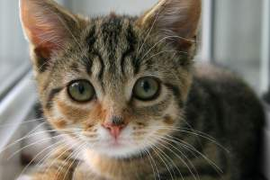

##### A kitten card

The image at the top of this card is from placekitten.com. It's very cute

Kitten A

Header

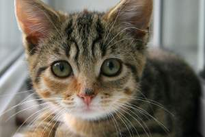

##### A kitten card

The image at the top of this card is from placekitten.com. It's very cute

Kitten B

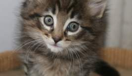

##### A kitten card

Quae fere omnia appellantur uno ingenii nomine, easque virtutes qui habent, ingeniosi vocantur. Gracchum patrem non beatiorem fuisse quam fillum, cum alter stabilire rem publicam studuerit, alter evertere. Qui ita affectus, beatum esse numquam probabis;

Kitten C

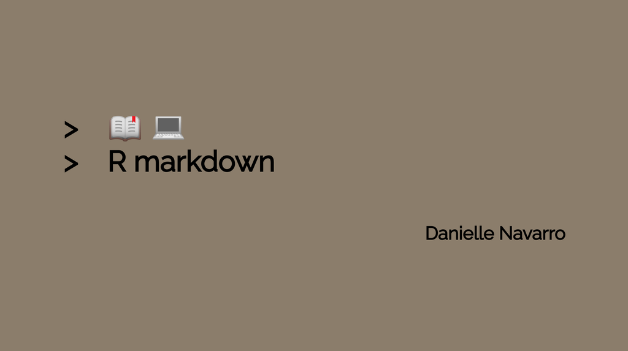

```r
library(bs4cards)
slides <- list(

  card(
    title = "Starting R markdown",
    image = "https://slides.djnavarro.net/index_img/starting-rmarkdown.png",
    link = "https://slides.djnavarro.net/starting-rmarkdown",
    text = "An introduction to R markdown. The target audience is a novice R user with no previous experience with markdown."
  ),

  card(
    title = "Starting ggplot2",
    image = "https://slides.djnavarro.net/index_img/starting-ggplot2.png",
    link = "https://slides.djnavarro.net/starting-ggplot2",
    text = "An introduction to ggplot2. The target audience is a novice user with no previous experience with R or ggplot2."
  ),

  card(
    title = "Starting programming",
    image = "https://slides.djnavarro.net/index_img/starting-programming.png",
    link = "https://slides.djnavarro.net/starting-programming",
    text = "This is primarily a tutorial on making generative art in R, but in doing so introduces core programming constructs and data structures. It is assumed the user has some previous experience with ggplot2."
  )
)
card_grid(slides)
```

##### Starting R markdown

An introduction to R markdown. The target audience is a novice R user with no previous experience with markdown.

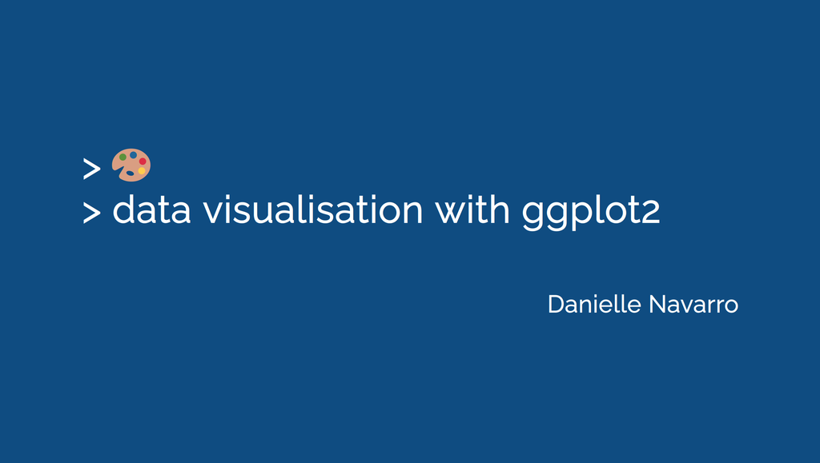

##### Starting ggplot2

An introduction to ggplot2. The target audience is a novice user with no previous experience with R or ggplot2.

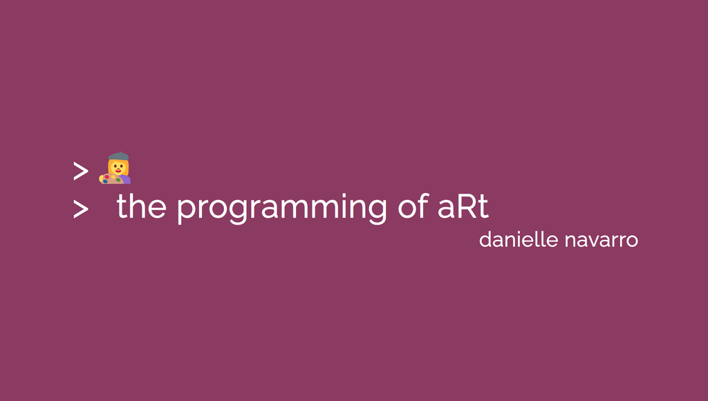

##### Starting programming

This is primarily a tutorial on making generative art in R, but in doing so introduces core programming constructs and data structures. It is assumed the user has some previous experience with ggplot2.

The goal of bs4cards is to make this task a little easier inside an R markdown document or website.